# Super-resolution with PyTorch

[figure not shown]

Marie-Hélène Burle

November 24, 2021

# Definitions

LR: low resolution

HR: high resolution

SR: super-resolution = reconstruction of HR images from LR images

SISR: single-image super-resolution = SR using a single input image

# History of super-resolution

## Can be broken down into 2 main periods:

- A rather slow history with various interpolation algorithms of increasing complexity before deep neural networks
- An incredibly fast evolution since the advent of deep learning (DL)

## SR history Pre-DL

Pixel-wise interpolation prior to DL

Various methods ranging from simple (e.g. [nearest-neighbour](https://en.wikipedia.org/wiki/Nearest-neighbor_interpolation), [bicubic](https://en.wikipedia.org/wiki/Bicubic_interpolation)) to complex (e.g. [Gaussian process regression](https://en.wikipedia.org/wiki/Kriging), [iterative FIR Wiener filter](https://en.wikipedia.org/wiki/Wiener_filter)) algorithms

## SR history Pre-DL

### [Nearest-neighbour interpolation](https://en.wikipedia.org/wiki/Nearest-neighbor_interpolation)

Simplest method of interpolation

Simply uses the value of the nearest pixel

### [Bicubic interpolation](https://en.wikipedia.org/wiki/Bicubic_interpolation)

Consists of determining the 16 coefficients $a_{ij}$ in:

$$p(x, y) = \sum_{i=0}^3\sum_{i=0}^3 a\_{ij} x^i y^j$$

## SR history with DL

Deep learning has seen a fast evolution marked by the successive emergence of various frameworks and architectures over the past 10 years

Some key network architectures and frameworks:

- CNN
- GAN
- Transformers

These have all been applied to SR

### SR using (amongst others):

- [Convolutional Neural Networks (SRCNN)](https://arxiv.org/abs/1501.00092) – 2014
- [Random Forests](https://www.cv-foundation.org/openaccess/content_cvpr_2015/html/Schulter_Fast_and_Accurate_2015_CVPR_paper.html) – 2015
- [Perceptual loss](https://link.springer.com/chapter/10.1007/978-3-319-46475-6_43) – 2016
- [Sub-pixel CNN](https://www.cv-foundation.org/openaccess/content_cvpr_2016/html/Shi_Real-Time_Single_Image_CVPR_2016_paper.html) – 2016
- [ResNet (SRResNet) & Generative Adversarial Network (SRGAN)](https://openaccess.thecvf.com/content_cvpr_2017/html/Ledig_Photo-Realistic_Single_Image_CVPR_2017_paper.html) – 2017
- [Enhanced SRGAN (ESRGAN)](https://openaccess.thecvf.com/content_eccv_2018_workshops/w25/html/Wang_ESRGAN_Enhanced_Super-Resolution_Generative_Adversarial_Networks_ECCVW_2018_paper.html) – 2018
- [Predictive Filter Flow (PFF)](https://arxiv.org/abs/1811.11482) – 2018
- [Densely Residual Laplacian attention Network (DRLN)](https://ieeexplore.ieee.org/abstract/document/9185010) – 2019
- [Second-order Attention Network (SAN)](https://openaccess.thecvf.com/content_CVPR_2019/html/Dai_Second-Order_Attention_Network_for_Single_Image_Super-Resolution_CVPR_2019_paper.html) – 2019
- [Learned downscaling with Content Adaptive Resampler (CAR)](https://ieeexplore.ieee.org/abstract/document/8982168) – 2019
- [Holistic Attention Network (HAN)](https://link.springer.com/chapter/10.1007/978-3-030-58610-2_12) – 2020
- [Swin Transformer](https://openaccess.thecvf.com/content/ICCV2021W/AIM/html/Liang_SwinIR_Image_Restoration_Using_Swin_Transformer_ICCVW_2021_paper.html) – 2021

## SRCNN

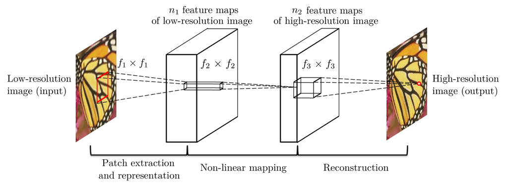

Dong, C., Loy, C. C., He, K., & Tang, X. (2015). Image super-resolution using deep convolutional networks. IEEE transactions on pattern analysis and machine intelligence, 38(2), 295-307

> Given a low-resolution image Y, the first convolutional layer of the SRCNN extracts a set of feature maps. The second layer maps these feature maps nonlinearly to high-resolution patch representations. The last layer combines the predictions within a spatial neighbourhood to produce the final high-resolution image F(Y)

## SRCNN

Can use sparse-coding-based methods

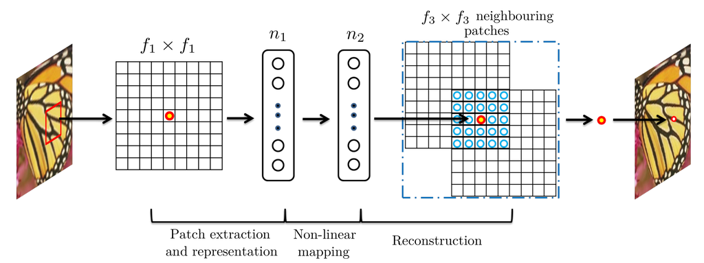

Dong, C., Loy, C. C., He, K., & Tang, X. (2015). Image super-resolution using deep convolutional networks. IEEE transactions on pattern analysis and machine intelligence, 38(2), 295-307

## SRGAN

Do not provide the best PSNR, but can give more realistic results by providing more texture (less smoothing)

## GAN

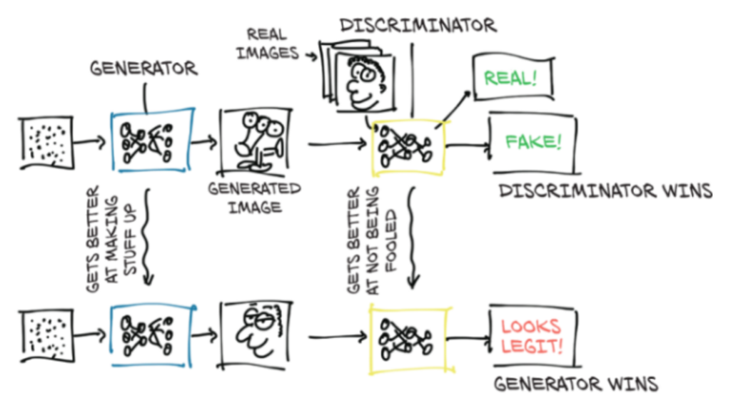

[Stevens E., Antiga L., & Viehmann T. (2020). Deep Learning with PyTorch](https://www.manning.com/books/deep-learning-with-pytorch)

## SRGAN

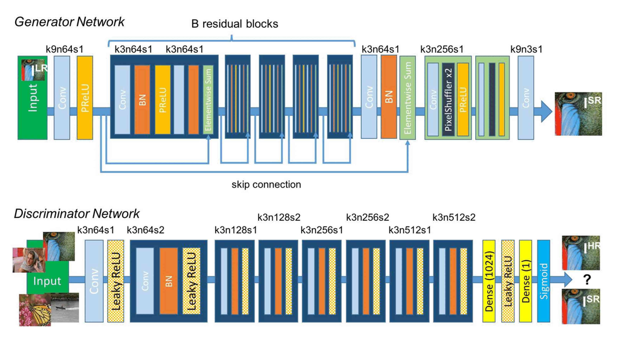

Ledig, C., Theis, L., Huszár, F., Caballero, J., Cunningham, A., Acosta, A., … & Shi, W. (2017). Photo-realistic single image super-resolution using a generative adversarial network. In Proceedings of the IEEE conference on computer vision and pattern recognition (pp. 4681-4690)

## SRGAN

Followed by the ESRGAN and many other flavours of SRGANs

# SwinIR

## Attention

(cited 2769 times)

(cited 30999 times…)

## Transformers

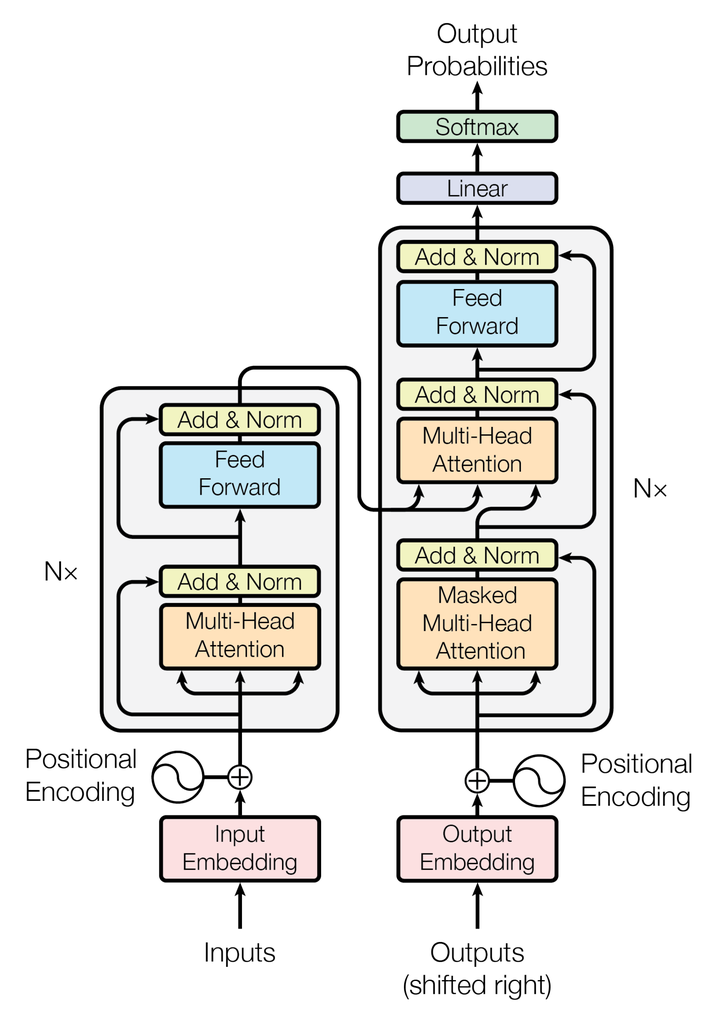

Vaswani, A., Shazeer, N., Parmar, N., Uszkoreit, J., Jones, L., Gomez, A. N., … & Polosukhin, I. (2017). Attention is all you need. In Advances in neural information processing systems (pp. 5998-6008)

## Transformers

Initially used for NLP to replace RNN as they allow parallelization Now entering the domain of vision and others Very performant with relatively few parameters

## Swin Transformer

The [Swin Transformer](https://arxiv.org/abs/2103.14030) improved the use of transformers to the vision domain

Swin = Shifted WINdows

## Swin Transformer

Swin transformer (left) vs transformer as initially applied to vision (right):

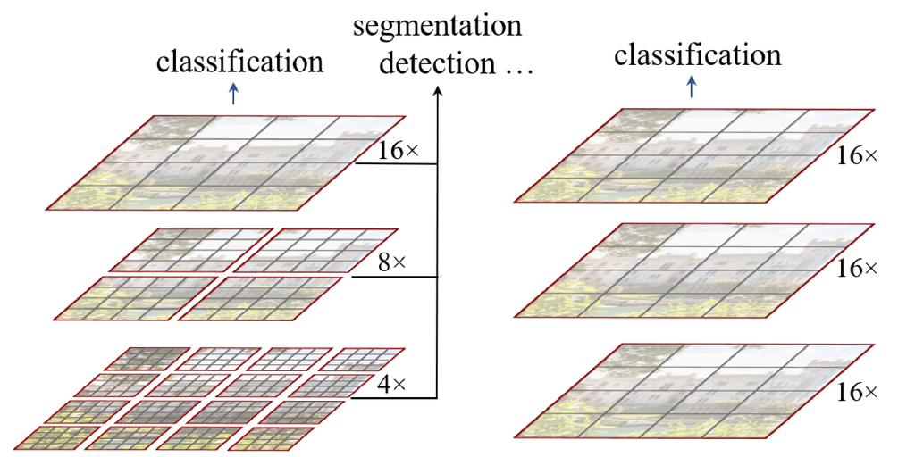

Liu, Z., Lin, Y., Cao, Y., Hu, H., Wei, Y., Zhang, Z., … & Guo, B. (2021). Swin transformer: Hierarchical vision transformer using shifted windows. arXiv preprint arXiv:2103.14030

## SwinIR

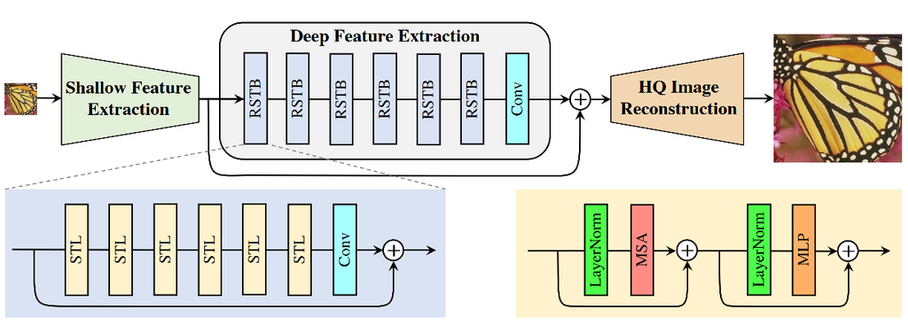

Liang, J., Cao, J., Sun, G., Zhang, K., Van Gool, L., & Timofte, R. (2021). SwinIR: Image restoration using swin transformer. In Proceedings of the IEEE/CVF International Conference on Computer Vision (pp. 1833-1844)

## Training sets used

[DIV2K](https://data.vision.ee.ethz.ch/cvl/DIV2K/), Flickr2K, and other datasets

## Models assessment

3 metrics commonly used:

#### [Peak signal-to-noise ratio (PSNR) measured in dB](https://en.wikipedia.org/wiki/Peak_signal-to-noise_ratio)

$\frac{\text{Maximum possible power of signal}}{\text{Power of noise (calculated as the mean squared error)}}$

Calculated at the pixel level

#### [Structural similarity index measure (SSIM)](https://en.wikipedia.org/wiki/Structural_similarity)

Prediction of perceived image quality based on a “perfect” reference image

#### [Mean opinion score (MOS)](https://en.wikipedia.org/wiki/Mean_opinion_score)

Mean of subjective quality ratings

## Models assessment

### [Peak signal-to-noise ratio (PSNR) measured in dB](https://en.wikipedia.org/wiki/Peak_signal-to-noise_ratio)

$$PSNR = 10\,\cdot\,log_{10}\,\left(\frac{MAX_I^2}{MSE}\right)$$

### [Structural similarity index measure (SSIM)](https://en.wikipedia.org/wiki/Structural_similarity)

$$SSIM(x,y) = \frac{(2\mu_x\mu_y + c_1) + (2 \sigma _{xy} + c_2)}
{(\mu_x^2 + \mu_y^2+c_1) (\sigma_x^2 + \sigma_y^2+c_2)}$$

### [Mean opinion score (MOS)](https://en.wikipedia.org/wiki/Mean_opinion_score)

$$MOS = \frac{\sum_{n=1}^N R\_n}{N}$$

## Metrics implementation

- Implement them yourself (using `torch.log10`, etc.)
- Use some library that implements them (e.g. [kornia](https://github.com/kornia/kornia/tree/master/kornia/losses))
- Use code of open source project with good implementation (e.g. [SwinIR](https://github.com/JingyunLiang/SwinIR/blob/main/utils/util_calculate_psnr_ssim.py))
- Use some higher level library that provides them (e.g. [ignite](https://pytorch.org/ignite/metrics.html))

## Metrics implementation

- Implement them yourself (using `torch.log10`, etc.)
- Use some library that implements them (e.g. [kornia](https://github.com/kornia/kornia/tree/master/kornia/losses))
- Use code of open source project with good implementation (e.g. [SwinIR](https://github.com/JingyunLiang/SwinIR/blob/main/utils/util_calculate_psnr_ssim.py))
- Use some higher level library that provides them (e.g. [ignite](https://pytorch.org/ignite/metrics.html))

## Metrics implementation

```python
import kornia

psnr_value = kornia.metrics.psnr(input, target, max_val)
ssim_value = kornia.metrics.ssim(img1, img2, window_size, max_val=1.0, eps=1e-12)
```

See the Kornia documentation for more info on kornia.metrics.psnr & kornia.metrics.ssim

## Benchmark datasets

### Set5

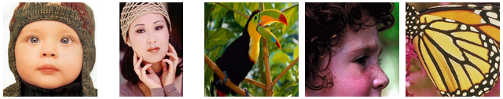

### Set14

[figure not shown]

### [BSD100 (Berkeley Segmentation Dataset)](https://huggingface.co/datasets/eugenesiow/BSD100)

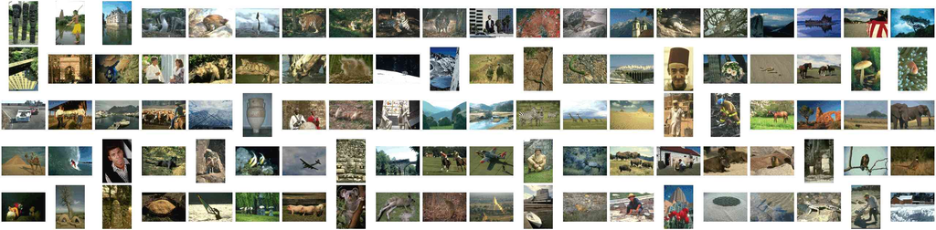

## Benchmark datasets

### Set5

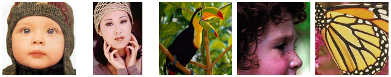

### Set14

[figure not shown]

### [BSD100 (Berkeley Segmentation Dataset)](https://huggingface.co/datasets/eugenesiow/BSD100)

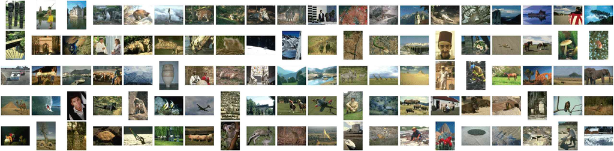

## How to get the dataset?

From the [HuggingFace Datasets Hub](https://huggingface.co/datasets) with the HuggingFace [datasets](https://pypi.org/project/datasets/) package:

```python
from datasets import load_dataset

set5 = load_dataset('eugenesiow/Set5', 'bicubic_x4', split='validation')
```

## Dataset exploration

```python
print(set5)
len(set5)
set5[0]
set5.shape
set5.column_names
set5.features
set5.set_format('torch', columns=['hr', 'lr'])
set5.format
```

## Benchmarks

[A 2012 review of interpolation methods for SR](https://ieeexplore.ieee.org/abstract/document/6411957) gives the metrics for a series of interpolation methods (using other datasets)

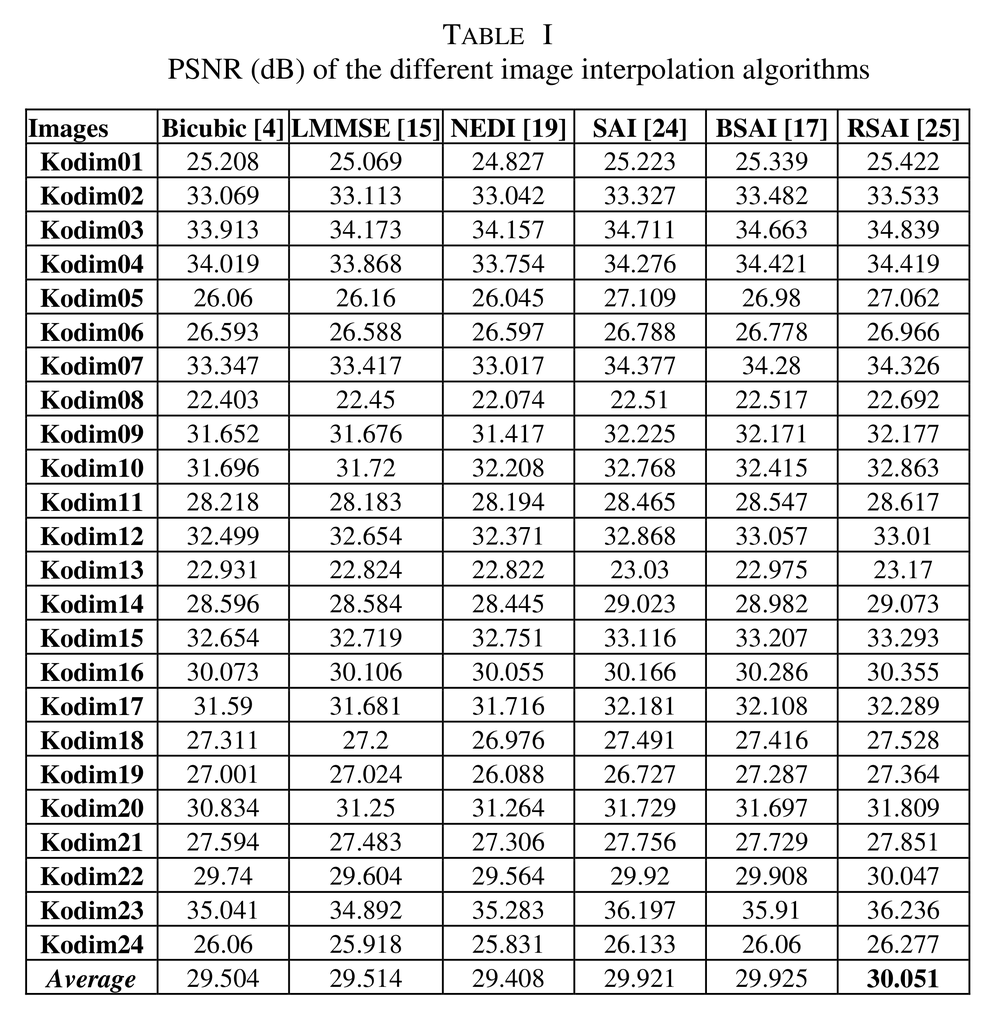

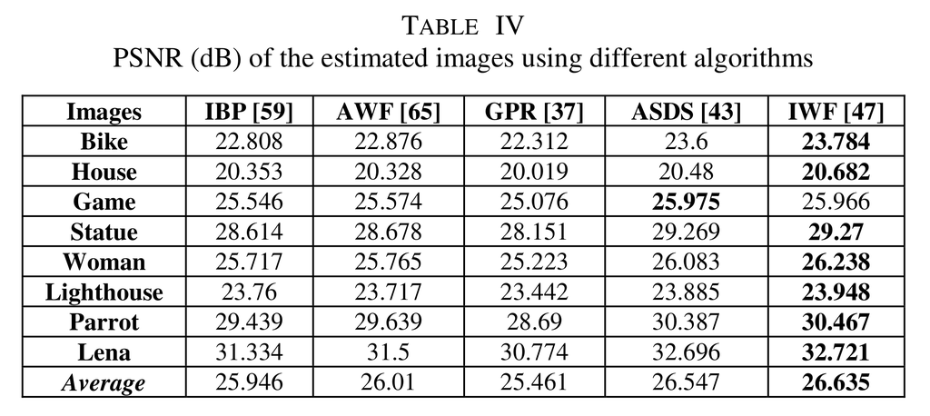

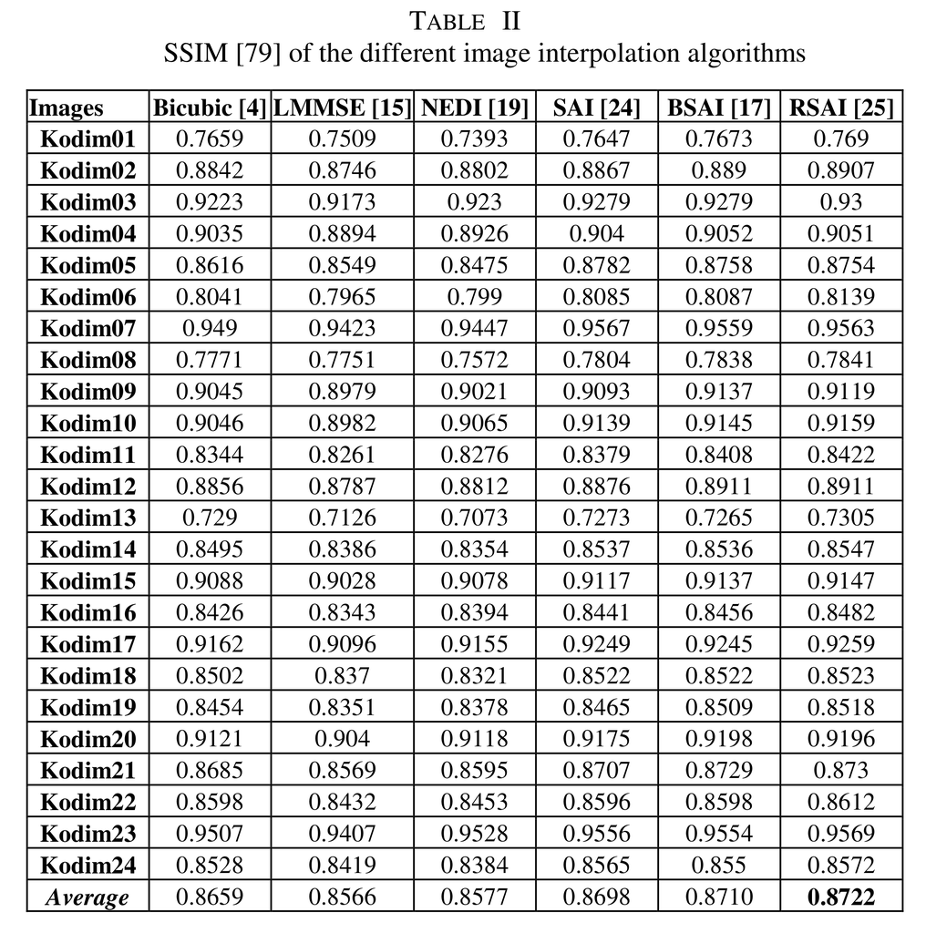

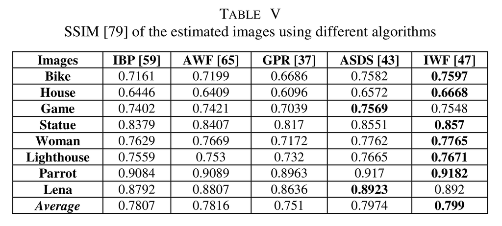

## Interpolation methods

[figure not shown]

## DL methods

The now defunct Papers with Code website used to list the available benchmarks on Set5

[figure not shown]

from the Papers with Code website (now defunct)

#### PSNR vs number of parameters for different methods on Set5x4

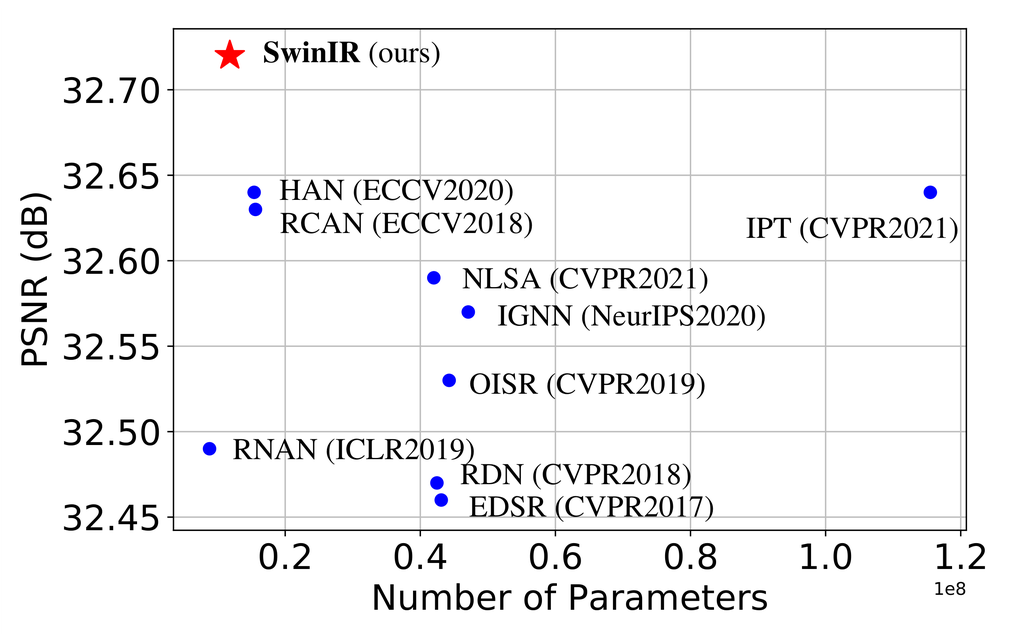

Liang, J., Cao, J., Sun, G., Zhang, K., Van Gool, L., & Timofte, R. (2021). SwinIR: Image restoration using swin transformer. In Proceedings of the IEEE/CVF International Conference on Computer Vision (pp. 1833-1844)

#### Comparison between SwinIR & a representative CNN-based model (RCAN) on classical SR images x4

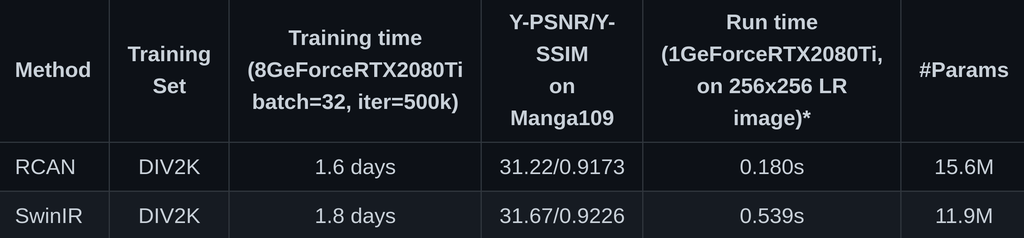

Liang, J., Cao, J., Sun, G., Zhang, K., Van Gool, L., & Timofte, R. (2021). SwinIR: Image restoration using swin transformer. In Proceedings of the IEEE/CVF International Conference on Computer Vision (pp. 1833-1844)

#### Comparison between SwinIR & a representative CNN-based model (RCAN) on classical SR images x4

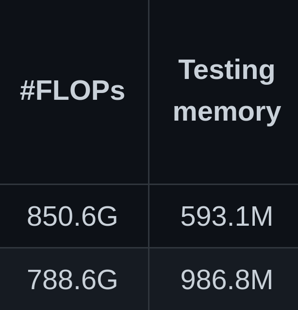

Liang, J., Cao, J., Sun, G., Zhang, K., Van Gool, L., & Timofte, R. (2021). SwinIR: Image restoration using swin transformer. In Proceedings of the IEEE/CVF International Conference on Computer Vision (pp. 1833-1844)

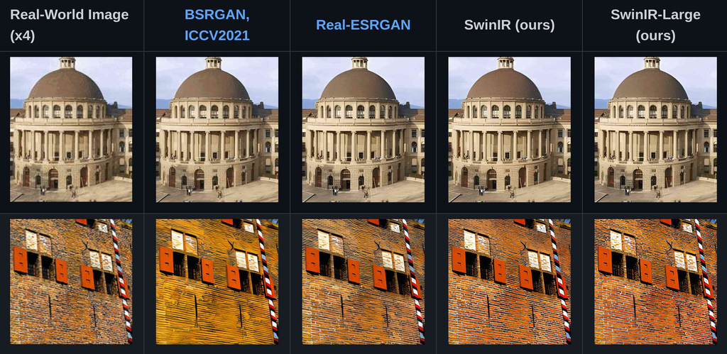

Liang, J., Cao, J., Sun, G., Zhang, K., Van Gool, L., & Timofte, R. (2021). SwinIR: Image restoration using swin transformer. In Proceedings of the IEEE/CVF International Conference on Computer Vision (pp. 1833-1844)

## Let’s use SwinIR

```bash
# Get the model
git clone git@github.com:JingyunLiang/SwinIR.git
cd SwinIR

# Copy our test images in the repo
cp -r <some/path>/my_tests /testsets/my_tests

# Run the model on our images
python main_test_swinir.py --tile 400 --task real_sr --scale 4 --large_model --model_path model_zoo/swinir/003_realSR_BSRGAN_DFOWMFC_s64w8_SwinIR-L_x4_GAN.pth --folder_lq testsets/my_tests
```

Ran in 9 min on my machine with one GPU and 32GB of RAM

## Results

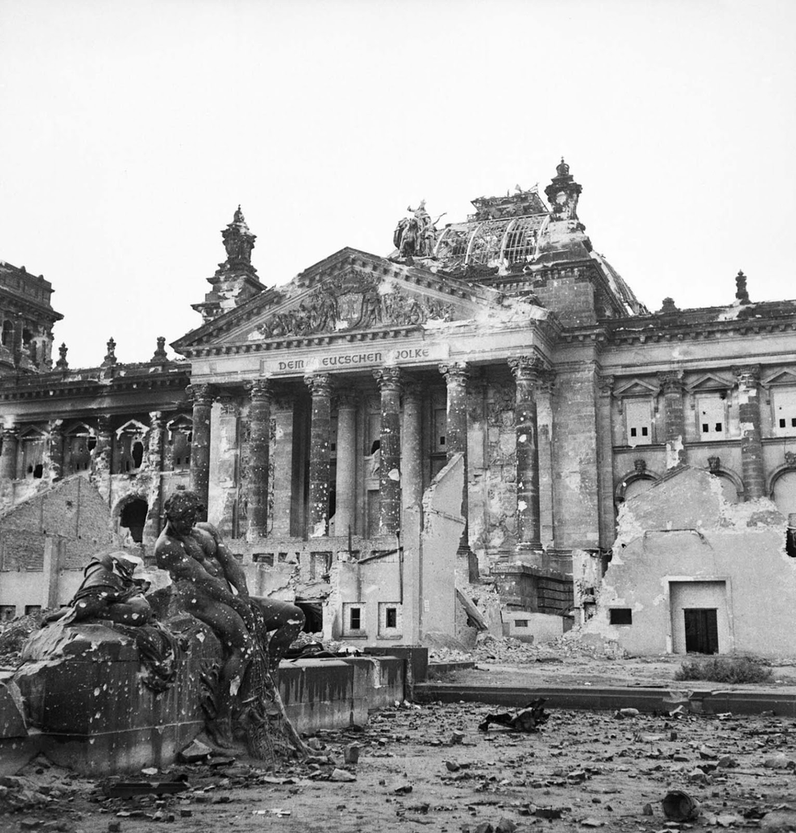

[figure not shown]

## Results

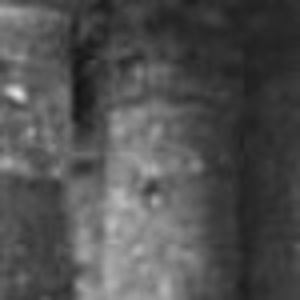

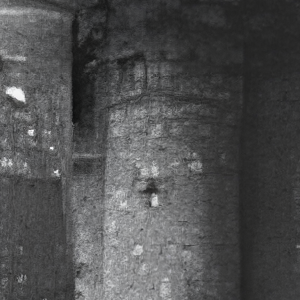

## Results

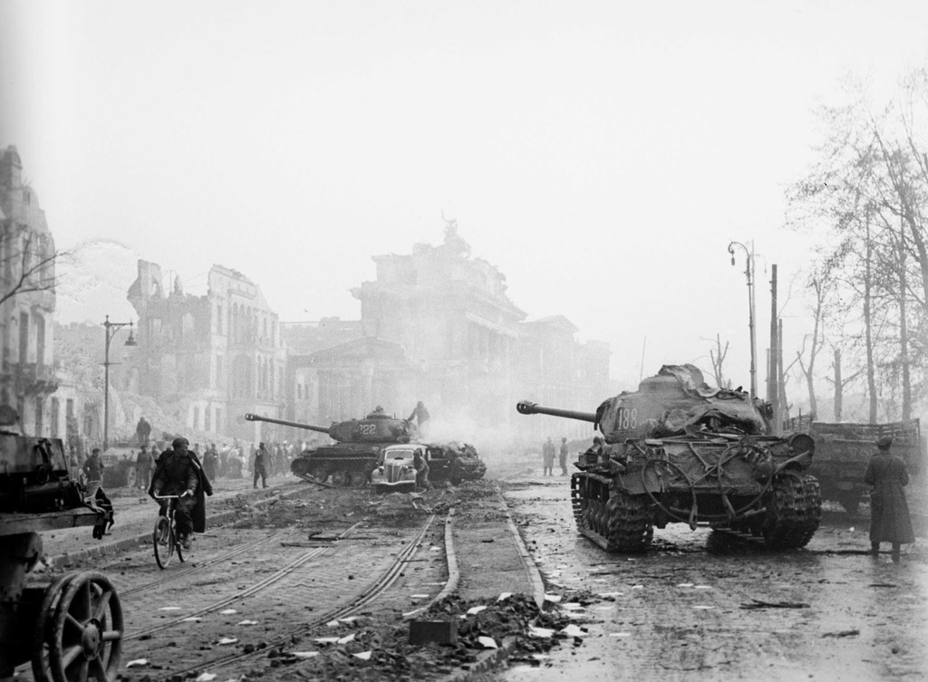

[figure not shown]

## Results

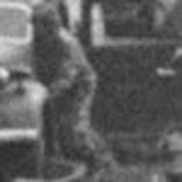

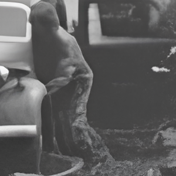

## Results

[figure not shown]

[figure not shown]